# HW_2_DATA606_ALEXANDER_NICULESCU

alexander niculescu

9/13/2018

Graded: 2.6, 2.8, 2.20, 2.30, 2.38, 2.44

2.6 Dice rolls. If you roll a pair of fair dice, what is the probability of (a) getting a sum of 1? 0 (b) getting a sum of 5? 2,3 3,2 1,4 4,1 : 4/36 (c) getting a sum of 12? 1/36

2.8 Poverty and language. The American Community Survey is an ongoing survey that provides data every year to give communities the current information they need to plan investments and services. The 2010 American Community Survey estimates that 14.6% of Americans live below the poverty line, 20.7% speak a language other than English (foreign language) at home, and 4.2% fall into both categories. (a) Are living below the poverty line and speaking a foreign language at home disjoint? No (b) Draw a Venn diagram summarizing the variables and their associated probabilities.

```r
library(VennDiagram)
```

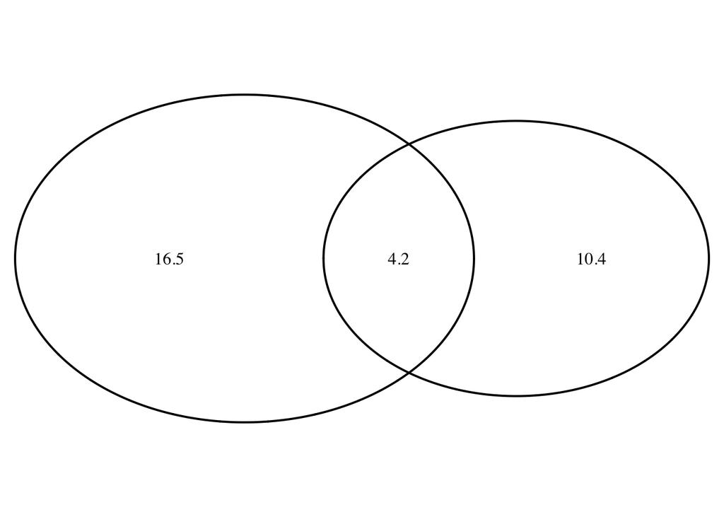

```
## (polygon[GRID.polygon.1], polygon[GRID.polygon.2], polygon[GRID.polygon.3], polygon[GRID.polygon.4], text[GRID.text.5], text[GRID.text.6], text[GRID.text.7], text[GRID.text.8], text[GRID.text.9])
```

```r
library(grid)
draw.pairwise.venn(area1 = 14.6, area2 = 20.7, cross.area = 4.2);
```

3. What percent of Americans live below the poverty line and only speak English at home? P(14.6-4.2)
4. What percent of Americans live below the poverty line or speak a foreign language at home? 14.6 + 20.7 - 4.2
5. What percent of Americans live above the poverty line and only speak English at home? 100 - 14.6 - 20.7 + 4.2
6. Is the event that someone lives below the poverty line independent of the event that the person speaks a foreign language at home? No

2.20 Assortative mating. Assortative mating is a nonrandom mating pattern where individuals with similar genotypes and/or phenotypes mate with one another more frequently than what would be expected under a random mating pattern. Researchers studying this topic collected data on eye colors of 204 Scandinavian men and their female partners. The table below summarizes the results. For simplicity, we only include heterosexual relationships in this exercise. Self(Male), Partner(Female) Blue Brown Green Total Blue 78 23 13 114 Brown 19 23 12 54 Green 11 9 16 36 Total 108 55 41 204

2.30 Books on a bookshelf. The table below shows the distribution of books on a bookcase based on whether they are nonfiction or fiction and hardcover or paperback. Type Fiction Nonfiction Total

```
        Hardcover Paperback Total
```

Fiction 13 59 72 Non Fiction 15 8 23 Total 28 67 95

1. Find the probability of drawing a hardcover book first then a paperback fiction book second when drawing without replacement. 28/95 * 59/94
2. Determine the probability of drawing a fiction book first and then a hardcover book second, when drawing without replacement. 72/95 * 28/94
3. Calculate the probability of the scenario in part (b), except this time complete the calculations under the scenario where the first book is placed back on the bookcase before randomly drawing the second book. 72/95 * 28/95
4. The final answers to parts (b) and (c) are very similar. Explain why this is the case. Replacement vs without replacement is just removing the first selection from the second set, or not.

2.38 Baggage fees. An airline charges the following baggage fees: $25 for the first bag and $35 for the second. Suppose 54% of passengers have no checked luggage, 34% have one piece of checked luggage and 12% have two pieces. We suppose a negligible portion of people check more than two bags. (a) Build a probability model, compute the average revenue per passenger, and compute the corresponding standard deviation. # | $ | P | $*P 0 | 0 | .54 | 0 1 | 25 | .34 | 8.5 2 | 35 | .12 | 4.2

```r
baggagePrice <- data.frame(0, 25, 35)
baggageProb  <- data.frame(.54, .34, .12)
sd(baggagePrice)
```

```
## [1] 18.02776
```